# Risk Factor Analysis

## Outcome Variable

**Outcome Variable:** haz

## Predictor Variables

**Intervention Variable:** vagbrth

**Adjustment Set:**

- arm
- sex
- W_mage
- meducyrs
- feducyrs
- hhwealth_quart
- W_mhtcm
- W_mwtkg
- W_mbmi
- single
- W_nrooms
- brthmon
- W_parity
- impfloor
- delta_W_mage
- delta_meducyrs
- delta_feducyrs
- delta_hhwealth_quart
- delta_W_mhtcm
- delta_W_mwtkg
- delta_W_mbmi
- delta_single
- delta_W_nrooms
- delta_brthmon
- delta_W_parity
- delta_impfloor

## Stratifying Variables

The analysis was stratified on these variable(s):

- agecat
- studyid
- country

## Data Summary

| agecat | studyid | country | vagbrth | n_cell | n | outcome_variable |
| --- | --- | --- | --- | --- | --- | --- |
| Birth | CMC-V-BCS-2002 | INDIA | 0 | 11 | 92 | haz |
| Birth | CMC-V-BCS-2002 | INDIA | 1 | 81 | 92 | haz |
| Birth | IRC | INDIA | 0 | 68 | 388 | haz |
| Birth | IRC | INDIA | 1 | 320 | 388 | haz |
| Birth | JiVitA-3 | BANGLADESH | 0 | 539 | 22418 | haz |
| Birth | JiVitA-3 | BANGLADESH | 1 | 21879 | 22418 | haz |
| Birth | JiVitA-4 | BANGLADESH | 0 | 76 | 2822 | haz |
| Birth | JiVitA-4 | BANGLADESH | 1 | 2746 | 2822 | haz |
| Birth | NIH-Crypto | BANGLADESH | 0 | 186 | 477 | haz |
| Birth | NIH-Crypto | BANGLADESH | 1 | 291 | 477 | haz |
| Birth | PROBIT | BELARUS | 0 | 1597 | 13893 | haz |
| Birth | PROBIT | BELARUS | 1 | 12296 | 13893 | haz |
| Birth | PROVIDE | BANGLADESH | 0 | 108 | 539 | haz |
| Birth | PROVIDE | BANGLADESH | 1 | 431 | 539 | haz |
| Birth | ZVITAMBO | ZIMBABWE | 0 | 1166 | 13761 | haz |
| Birth | ZVITAMBO | ZIMBABWE | 1 | 12595 | 13761 | haz |
| 6 months | CMC-V-BCS-2002 | INDIA | 0 | 25 | 369 | haz |
| 6 months | CMC-V-BCS-2002 | INDIA | 1 | 344 | 369 | haz |
| 6 months | IRC | INDIA | 0 | 69 | 407 | haz |
| 6 months | IRC | INDIA | 1 | 338 | 407 | haz |
| 6 months | JiVitA-3 | BANGLADESH | 0 | 1077 | 16732 | haz |
| 6 months | JiVitA-3 | BANGLADESH | 1 | 15655 | 16732 | haz |
| 6 months | JiVitA-4 | BANGLADESH | 0 | 336 | 4052 | haz |
| 6 months | JiVitA-4 | BANGLADESH | 1 | 3716 | 4052 | haz |
| 6 months | NIH-Crypto | BANGLADESH | 0 | 187 | 457 | haz |
| 6 months | NIH-Crypto | BANGLADESH | 1 | 270 | 457 | haz |
| 6 months | PROBIT | BELARUS | 0 | 1799 | 15760 | haz |
| 6 months | PROBIT | BELARUS | 1 | 13961 | 15760 | haz |
| 6 months | PROVIDE | BANGLADESH | 0 | 139 | 604 | haz |
| 6 months | PROVIDE | BANGLADESH | 1 | 465 | 604 | haz |
| 6 months | TanzaniaChild2 | TANZANIA, UNITED REPUBLIC OF | 0 | 189 | 2005 | haz |
| 6 months | TanzaniaChild2 | TANZANIA, UNITED REPUBLIC OF | 1 | 1816 | 2005 | haz |
| 6 months | ZVITAMBO | ZIMBABWE | 0 | 740 | 8601 | haz |
| 6 months | ZVITAMBO | ZIMBABWE | 1 | 7861 | 8601 | haz |
| 24 months | CMC-V-BCS-2002 | INDIA | 0 | 24 | 371 | haz |
| 24 months | CMC-V-BCS-2002 | INDIA | 1 | 347 | 371 | haz |
| 24 months | IRC | INDIA | 0 | 69 | 409 | haz |
| 24 months | IRC | INDIA | 1 | 340 | 409 | haz |
| 24 months | JiVitA-3 | BANGLADESH | 0 | 480 | 8584 | haz |
| 24 months | JiVitA-3 | BANGLADESH | 1 | 8104 | 8584 | haz |
| 24 months | JiVitA-4 | BANGLADESH | 0 | 323 | 4020 | haz |
| 24 months | JiVitA-4 | BANGLADESH | 1 | 3697 | 4020 | haz |
| 24 months | NIH-Crypto | BANGLADESH | 0 | 99 | 260 | haz |
| 24 months | NIH-Crypto | BANGLADESH | 1 | 161 | 260 | haz |
| 24 months | PROBIT | BELARUS | 0 | 472 | 4035 | haz |
| 24 months | PROBIT | BELARUS | 1 | 3563 | 4035 | haz |
| 24 months | PROVIDE | BANGLADESH | 0 | 137 | 578 | haz |
| 24 months | PROVIDE | BANGLADESH | 1 | 441 | 578 | haz |
| 24 months | TanzaniaChild2 | TANZANIA, UNITED REPUBLIC OF | 0 | 2 | 6 | haz |
| 24 months | TanzaniaChild2 | TANZANIA, UNITED REPUBLIC OF | 1 | 4 | 6 | haz |
| 24 months | ZVITAMBO | ZIMBABWE | 0 | 133 | 1619 | haz |
| 24 months | ZVITAMBO | ZIMBABWE | 1 | 1486 | 1619 | haz |

The following strata were considered:

- agecat: 24 months, studyid: CMC-V-BCS-2002, country: INDIA
- agecat: 24 months, studyid: IRC, country: INDIA
- agecat: 24 months, studyid: JiVitA-3, country: BANGLADESH
- agecat: 24 months, studyid: JiVitA-4, country: BANGLADESH
- agecat: 24 months, studyid: NIH-Crypto, country: BANGLADESH
- agecat: 24 months, studyid: PROBIT, country: BELARUS
- agecat: 24 months, studyid: PROVIDE, country: BANGLADESH
- agecat: 24 months, studyid: TanzaniaChild2, country: TANZANIA, UNITED REPUBLIC OF
- agecat: 24 months, studyid: ZVITAMBO, country: ZIMBABWE
- agecat: 6 months, studyid: CMC-V-BCS-2002, country: INDIA
- agecat: 6 months, studyid: IRC, country: INDIA
- agecat: 6 months, studyid: JiVitA-3, country: BANGLADESH
- agecat: 6 months, studyid: JiVitA-4, country: BANGLADESH
- agecat: 6 months, studyid: NIH-Crypto, country: BANGLADESH
- agecat: 6 months, studyid: PROBIT, country: BELARUS
- agecat: 6 months, studyid: PROVIDE, country: BANGLADESH
- agecat: 6 months, studyid: TanzaniaChild2, country: TANZANIA, UNITED REPUBLIC OF
- agecat: 6 months, studyid: ZVITAMBO, country: ZIMBABWE
- agecat: Birth, studyid: CMC-V-BCS-2002, country: INDIA
- agecat: Birth, studyid: IRC, country: INDIA
- agecat: Birth, studyid: JiVitA-3, country: BANGLADESH
- agecat: Birth, studyid: JiVitA-4, country: BANGLADESH
- agecat: Birth, studyid: NIH-Crypto, country: BANGLADESH
- agecat: Birth, studyid: PROBIT, country: BELARUS
- agecat: Birth, studyid: PROVIDE, country: BANGLADESH
- agecat: Birth, studyid: ZVITAMBO, country: ZIMBABWE

### Dropped Strata

Some strata were dropped due to rare outcomes:

- agecat: 24 months, studyid: TanzaniaChild2, country: TANZANIA, UNITED REPUBLIC OF

## Methods Detail

We’re interested in the causal parameters $E[Y_a]$ for all values of $a \in \mathcal{A}$. These parameters represent the mean outcome if, possibly contrary to fact, we intervened to set all units to have $A=a$. Under the randomization and positivity assumptions, these are identified by the statistical parameters $\psi_a=E_W[E_{Y|A,W}(Y|A=a,W)]$. In addition, we’re interested in the mean of $Y$, $E[Y]$ under no intervention (the observed mean). We will estimate these parameters by using SuperLearner to fit the relevant likelihood factors – $E_{Y|A,W}(Y|A=a,W)$ and $p(A=a|W)$, and then updating our likelihood fit using a joint TMLE.

For unadjusted analyses ($W=\{\}$), initial likelihoods were estimated using Lrnr_glm to estimate the simple $E(Y|A)$ and Lrnr_mean to estimate $p(A)$. For adjusted analyses, a small library containing Lrnr_glmnet, Lrnr_xgboost, and Lrnr_mean was used.

Having estimated these parameters, we will then use the delta method to estimate relative risks and attributable risks relative to a prespecified baseline level of $A$.

# Results Detail

## Results Plots

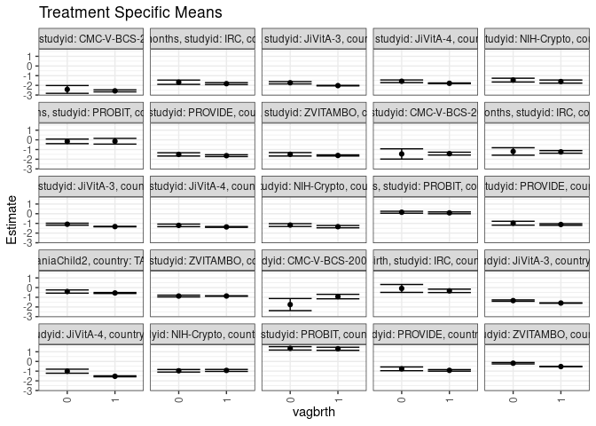

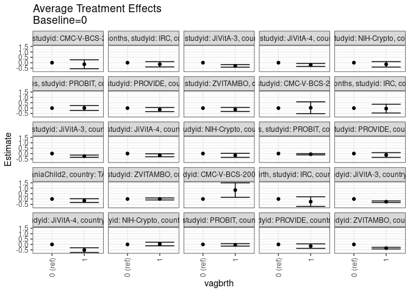

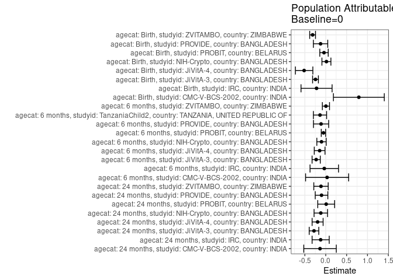

## Results Table

### Parameter: TSM

| agecat | studyid | country | intervention_level | baseline_level | estimate | ci_lower | ci_upper |
| --- | --- | --- | --- | --- | --- | --- | --- |
| Birth | CMC-V-BCS-2002 | INDIA | 0 | NA | -1.7544362 | -2.3788327 | -1.1300398 |
| Birth | CMC-V-BCS-2002 | INDIA | 1 | NA | -0.9295420 | -1.1613891 | -0.6976948 |
| Birth | IRC | INDIA | 0 | NA | -0.0878487 | -0.4982408 | 0.3225434 |
| Birth | IRC | INDIA | 1 | NA | -0.3358032 | -0.5116710 | -0.1599354 |
| Birth | JiVitA-3 | BANGLADESH | 0 | NA | -1.3439263 | -1.4148964 | -1.2729561 |
| Birth | JiVitA-3 | BANGLADESH | 1 | NA | -1.5964148 | -1.6159535 | -1.5768762 |
| Birth | JiVitA-4 | BANGLADESH | 0 | NA | -1.0055130 | -1.2160879 | -0.7949381 |
| Birth | JiVitA-4 | BANGLADESH | 1 | NA | -1.5315511 | -1.5821379 | -1.4809642 |
| Birth | NIH-Crypto | BANGLADESH | 0 | NA | -0.9643177 | -1.0977469 | -0.8308885 |
| Birth | NIH-Crypto | BANGLADESH | 1 | NA | -0.9249446 | -1.0282228 | -0.8216664 |
| Birth | PROBIT | BELARUS | 0 | NA | 1.3528069 | 1.1775595 | 1.5280542 |
| Birth | PROBIT | BELARUS | 1 | NA | 1.3102156 | 1.1487162 | 1.4717151 |
| Birth | PROVIDE | BANGLADESH | 0 | NA | -0.7611071 | -0.9553160 | -0.5668982 |
| Birth | PROVIDE | BANGLADESH | 1 | NA | -0.9201046 | -1.0012369 | -0.8389724 |
| Birth | ZVITAMBO | ZIMBABWE | 0 | NA | -0.1824230 | -0.2548667 | -0.1099794 |
| Birth | ZVITAMBO | ZIMBABWE | 1 | NA | -0.5272395 | -0.5488063 | -0.5056727 |
| 6 months | CMC-V-BCS-2002 | INDIA | 0 | NA | -1.4564244 | -1.9866032 | -0.9262457 |
| 6 months | CMC-V-BCS-2002 | INDIA | 1 | NA | -1.4238767 | -1.5709013 | -1.2768522 |
| 6 months | IRC | INDIA | 0 | NA | -1.1995222 | -1.5853003 | -0.8137441 |
| 6 months | IRC | INDIA | 1 | NA | -1.2437441 | -1.3805745 | -1.1069138 |
| 6 months | JiVitA-3 | BANGLADESH | 0 | NA | -1.0843770 | -1.1856043 | -0.9831497 |
| 6 months | JiVitA-3 | BANGLADESH | 1 | NA | -1.3284459 | -1.3516172 | -1.3052746 |
| 6 months | JiVitA-4 | BANGLADESH | 0 | NA | -1.2039593 | -1.3365647 | -1.0713539 |
| 6 months | JiVitA-4 | BANGLADESH | 1 | NA | -1.3642645 | -1.4083694 | -1.3201596 |
| 6 months | NIH-Crypto | BANGLADESH | 0 | NA | -1.1716529 | -1.3155040 | -1.0278018 |
| 6 months | NIH-Crypto | BANGLADESH | 1 | NA | -1.3383117 | -1.4566187 | -1.2200047 |
| 6 months | PROBIT | BELARUS | 0 | NA | 0.1525624 | 0.0521315 | 0.2529934 |
| 6 months | PROBIT | BELARUS | 1 | NA | 0.0910377 | -0.0013442 | 0.1834196 |
| 6 months | PROVIDE | BANGLADESH | 0 | NA | -0.9798163 | -1.1819201 | -0.7777124 |
| 6 months | PROVIDE | BANGLADESH | 1 | NA | -1.1123993 | -1.1962882 | -1.0285103 |
| 6 months | TanzaniaChild2 | TANZANIA, UNITED REPUBLIC OF | 0 | NA | -0.4082201 | -0.5744579 | -0.2419823 |
| 6 months | TanzaniaChild2 | TANZANIA, UNITED REPUBLIC OF | 1 | NA | -0.5568368 | -0.6085054 | -0.5051683 |
| 6 months | ZVITAMBO | ZIMBABWE | 0 | NA | -0.8735528 | -0.9629844 | -0.7841213 |
| 6 months | ZVITAMBO | ZIMBABWE | 1 | NA | -0.8695389 | -0.8964930 | -0.8425848 |
| 24 months | CMC-V-BCS-2002 | INDIA | 0 | NA | -2.4220813 | -2.8247274 | -2.0194353 |
| 24 months | CMC-V-BCS-2002 | INDIA | 1 | NA | -2.5685744 | -2.6714066 | -2.4657423 |
| 24 months | IRC | INDIA | 0 | NA | -1.6770212 | -1.8997727 | -1.4542696 |
| 24 months | IRC | INDIA | 1 | NA | -1.8253770 | -1.9284132 | -1.7223409 |
| 24 months | JiVitA-3 | BANGLADESH | 0 | NA | -1.7329935 | -1.8524806 | -1.6135063 |
| 24 months | JiVitA-3 | BANGLADESH | 1 | NA | -2.0283503 | -2.0559992 | -2.0007015 |
| 24 months | JiVitA-4 | BANGLADESH | 0 | NA | -1.5787151 | -1.7155561 | -1.4418741 |
| 24 months | JiVitA-4 | BANGLADESH | 1 | NA | -1.7881090 | -1.8277770 | -1.7484411 |
| 24 months | NIH-Crypto | BANGLADESH | 0 | NA | -1.4595976 | -1.6548959 | -1.2642993 |
| 24 months | NIH-Crypto | BANGLADESH | 1 | NA | -1.6102617 | -1.7719049 | -1.4486186 |
| 24 months | PROBIT | BELARUS | 0 | NA | -0.1551717 | -0.3925905 | 0.0822472 |
| 24 months | PROBIT | BELARUS | 1 | NA | -0.1436733 | -0.4395822 | 0.1522356 |
| 24 months | PROVIDE | BANGLADESH | 0 | NA | -1.5016810 | -1.6709303 | -1.3324317 |
| 24 months | PROVIDE | BANGLADESH | 1 | NA | -1.6342064 | -1.7278435 | -1.5405693 |
| 24 months | ZVITAMBO | ZIMBABWE | 0 | NA | -1.4908829 | -1.6690410 | -1.3127248 |
| 24 months | ZVITAMBO | ZIMBABWE | 1 | NA | -1.6142112 | -1.6744616 | -1.5539608 |

### Parameter: E(Y)

| agecat | studyid | country | intervention_level | baseline_level | estimate | ci_lower | ci_upper |
| --- | --- | --- | --- | --- | --- | --- | --- |
| Birth | CMC-V-BCS-2002 | INDIA | NA | NA | -0.9611957 | -1.1776967 | -0.7446946 |
| Birth | IRC | INDIA | NA | NA | -0.3080412 | -0.4687931 | -0.1472894 |
| Birth | JiVitA-3 | BANGLADESH | NA | NA | -1.5892417 | -1.6084834 | -1.5700000 |
| Birth | JiVitA-4 | BANGLADESH | NA | NA | -1.5231680 | -1.5722488 | -1.4740872 |
| Birth | NIH-Crypto | BANGLADESH | NA | NA | -0.9480084 | -1.0301396 | -0.8658772 |
| Birth | PROBIT | BELARUS | NA | NA | 1.3114417 | 1.1524752 | 1.4704082 |
| Birth | PROVIDE | BANGLADESH | NA | NA | -0.8851020 | -0.9601332 | -0.8100709 |
| Birth | ZVITAMBO | ZIMBABWE | NA | NA | -0.4970772 | -0.5177022 | -0.4764523 |
| 6 months | CMC-V-BCS-2002 | INDIA | NA | NA | -1.4234508 | -1.5645974 | -1.2823042 |
| 6 months | IRC | INDIA | NA | NA | -1.2344062 | -1.3658524 | -1.1029600 |
| 6 months | JiVitA-3 | BANGLADESH | NA | NA | -1.3134013 | -1.3366073 | -1.2901952 |
| 6 months | JiVitA-4 | BANGLADESH | NA | NA | -1.3500888 | -1.3921730 | -1.3080047 |
| 6 months | NIH-Crypto | BANGLADESH | NA | NA | -1.2731619 | -1.3626957 | -1.1836282 |
| 6 months | PROBIT | BELARUS | NA | NA | 0.0980074 | 0.0062724 | 0.1897424 |
| 6 months | PROVIDE | BANGLADESH | NA | NA | -1.0916915 | -1.1661176 | -1.0172654 |
| 6 months | TanzaniaChild2 | TANZANIA, UNITED REPUBLIC OF | NA | NA | -0.5455565 | -0.5948696 | -0.4962435 |
| 6 months | ZVITAMBO | ZIMBABWE | NA | NA | -0.8685914 | -0.8942954 | -0.8428875 |
| 24 months | CMC-V-BCS-2002 | INDIA | NA | NA | -2.5588679 | -2.6583730 | -2.4593629 |
| 24 months | IRC | INDIA | NA | NA | -1.7987775 | -1.8923914 | -1.7051636 |
| 24 months | JiVitA-3 | BANGLADESH | NA | NA | -2.0144245 | -2.0420946 | -1.9867544 |
| 24 months | JiVitA-4 | BANGLADESH | NA | NA | -1.7734527 | -1.8119258 | -1.7349797 |
| 24 months | NIH-Crypto | BANGLADESH | NA | NA | -1.5776538 | -1.6988448 | -1.4564629 |
| 24 months | PROBIT | BELARUS | NA | NA | -0.1442891 | -0.4253755 | 0.1367972 |
| 24 months | PROVIDE | BANGLADESH | NA | NA | -1.6024221 | -1.6857420 | -1.5191023 |
| 24 months | ZVITAMBO | ZIMBABWE | NA | NA | -1.6043391 | -1.6616652 | -1.5470130 |

### Parameter: ATE

| agecat | studyid | country | intervention_level | baseline_level | estimate | ci_lower | ci_upper |
| --- | --- | --- | --- | --- | --- | --- | --- |
| Birth | CMC-V-BCS-2002 | INDIA | 0 | 0 | 0.0000000 | 0.0000000 | 0.0000000 |
| Birth | CMC-V-BCS-2002 | INDIA | 1 | 0 | 0.8248942 | 0.1529408 | 1.4968477 |
| Birth | IRC | INDIA | 0 | 0 | 0.0000000 | 0.0000000 | 0.0000000 |
| Birth | IRC | INDIA | 1 | 0 | -0.2479545 | -0.6961066 | 0.2001975 |
| Birth | JiVitA-3 | BANGLADESH | 0 | 0 | 0.0000000 | 0.0000000 | 0.0000000 |
| Birth | JiVitA-3 | BANGLADESH | 1 | 0 | -0.2524886 | -0.3242447 | -0.1807324 |
| Birth | JiVitA-4 | BANGLADESH | 0 | 0 | 0.0000000 | 0.0000000 | 0.0000000 |
| Birth | JiVitA-4 | BANGLADESH | 1 | 0 | -0.5260380 | -0.7416797 | -0.3103964 |
| Birth | NIH-Crypto | BANGLADESH | 0 | 0 | 0.0000000 | 0.0000000 | 0.0000000 |
| Birth | NIH-Crypto | BANGLADESH | 1 | 0 | 0.0393731 | -0.1283854 | 0.2071316 |
| Birth | PROBIT | BELARUS | 0 | 0 | 0.0000000 | 0.0000000 | 0.0000000 |
| Birth | PROBIT | BELARUS | 1 | 0 | -0.0425912 | -0.1564260 | 0.0712435 |
| Birth | PROVIDE | BANGLADESH | 0 | 0 | 0.0000000 | 0.0000000 | 0.0000000 |
| Birth | PROVIDE | BANGLADESH | 1 | 0 | -0.1589976 | -0.3692048 | 0.0512097 |
| Birth | ZVITAMBO | ZIMBABWE | 0 | 0 | 0.0000000 | 0.0000000 | 0.0000000 |
| Birth | ZVITAMBO | ZIMBABWE | 1 | 0 | -0.3448165 | -0.4202770 | -0.2693560 |
| 6 months | CMC-V-BCS-2002 | INDIA | 0 | 0 | 0.0000000 | 0.0000000 | 0.0000000 |
| 6 months | CMC-V-BCS-2002 | INDIA | 1 | 0 | 0.0325477 | -0.5198202 | 0.5849157 |
| 6 months | IRC | INDIA | 0 | 0 | 0.0000000 | 0.0000000 | 0.0000000 |
| 6 months | IRC | INDIA | 1 | 0 | -0.0442219 | -0.4523040 | 0.3638601 |
| 6 months | JiVitA-3 | BANGLADESH | 0 | 0 | 0.0000000 | 0.0000000 | 0.0000000 |
| 6 months | JiVitA-3 | BANGLADESH | 1 | 0 | -0.2440689 | -0.3464665 | -0.1416713 |
| 6 months | JiVitA-4 | BANGLADESH | 0 | 0 | 0.0000000 | 0.0000000 | 0.0000000 |
| 6 months | JiVitA-4 | BANGLADESH | 1 | 0 | -0.1603052 | -0.2987318 | -0.0218787 |
| 6 months | NIH-Crypto | BANGLADESH | 0 | 0 | 0.0000000 | 0.0000000 | 0.0000000 |
| 6 months | NIH-Crypto | BANGLADESH | 1 | 0 | -0.1666588 | -0.3531351 | 0.0198175 |
| 6 months | PROBIT | BELARUS | 0 | 0 | 0.0000000 | 0.0000000 | 0.0000000 |
| 6 months | PROBIT | BELARUS | 1 | 0 | -0.0615248 | -0.1211480 | -0.0019015 |
| 6 months | PROVIDE | BANGLADESH | 0 | 0 | 0.0000000 | 0.0000000 | 0.0000000 |
| 6 months | PROVIDE | BANGLADESH | 1 | 0 | -0.1325830 | -0.3517033 | 0.0865373 |
| 6 months | TanzaniaChild2 | TANZANIA, UNITED REPUBLIC OF | 0 | 0 | 0.0000000 | 0.0000000 | 0.0000000 |
| 6 months | TanzaniaChild2 | TANZANIA, UNITED REPUBLIC OF | 1 | 0 | -0.1486167 | -0.3220479 | 0.0248145 |
| 6 months | ZVITAMBO | ZIMBABWE | 0 | 0 | 0.0000000 | 0.0000000 | 0.0000000 |
| 6 months | ZVITAMBO | ZIMBABWE | 1 | 0 | 0.0040139 | -0.0888613 | 0.0968892 |
| 24 months | CMC-V-BCS-2002 | INDIA | 0 | 0 | 0.0000000 | 0.0000000 | 0.0000000 |
| 24 months | CMC-V-BCS-2002 | INDIA | 1 | 0 | -0.1464931 | -0.5620591 | 0.2690730 |
| 24 months | IRC | INDIA | 0 | 0 | 0.0000000 | 0.0000000 | 0.0000000 |
| 24 months | IRC | INDIA | 1 | 0 | -0.1483559 | -0.3939608 | 0.0972491 |
| 24 months | JiVitA-3 | BANGLADESH | 0 | 0 | 0.0000000 | 0.0000000 | 0.0000000 |
| 24 months | JiVitA-3 | BANGLADESH | 1 | 0 | -0.2953569 | -0.4154437 | -0.1752701 |
| 24 months | JiVitA-4 | BANGLADESH | 0 | 0 | 0.0000000 | 0.0000000 | 0.0000000 |
| 24 months | JiVitA-4 | BANGLADESH | 1 | 0 | -0.2093939 | -0.3497220 | -0.0690658 |
| 24 months | NIH-Crypto | BANGLADESH | 0 | 0 | 0.0000000 | 0.0000000 | 0.0000000 |
| 24 months | NIH-Crypto | BANGLADESH | 1 | 0 | -0.1506641 | -0.4038673 | 0.1025390 |
| 24 months | PROBIT | BELARUS | 0 | 0 | 0.0000000 | 0.0000000 | 0.0000000 |
| 24 months | PROBIT | BELARUS | 1 | 0 | 0.0114983 | -0.2162085 | 0.2392052 |
| 24 months | PROVIDE | BANGLADESH | 0 | 0 | 0.0000000 | 0.0000000 | 0.0000000 |
| 24 months | PROVIDE | BANGLADESH | 1 | 0 | -0.1325254 | -0.3238157 | 0.0587650 |
| 24 months | ZVITAMBO | ZIMBABWE | 0 | 0 | 0.0000000 | 0.0000000 | 0.0000000 |
| 24 months | ZVITAMBO | ZIMBABWE | 1 | 0 | -0.1233283 | -0.3110806 | 0.0644240 |

### Parameter: PAR

| agecat | studyid | country | intervention_level | baseline_level | estimate | ci_lower | ci_upper |
| --- | --- | --- | --- | --- | --- | --- | --- |
| Birth | CMC-V-BCS-2002 | INDIA | 0 | NA | 0.7932406 | 0.1838032 | 1.4026779 |
| Birth | IRC | INDIA | 0 | NA | -0.2201925 | -0.5925278 | 0.1521427 |
| Birth | JiVitA-3 | BANGLADESH | 0 | NA | -0.2453154 | -0.3147308 | -0.1759001 |
| Birth | JiVitA-4 | BANGLADESH | 0 | NA | -0.5176549 | -0.7264456 | -0.3088642 |
| Birth | NIH-Crypto | BANGLADESH | 0 | NA | 0.0163093 | -0.0912499 | 0.1238686 |
| Birth | PROBIT | BELARUS | 0 | NA | -0.0413651 | -0.1424158 | 0.0596855 |
| Birth | PROVIDE | BANGLADESH | 0 | NA | -0.1239950 | -0.2961385 | 0.0481486 |
| Birth | ZVITAMBO | ZIMBABWE | 0 | NA | -0.3146542 | -0.3842045 | -0.2451039 |
| 6 months | CMC-V-BCS-2002 | INDIA | 0 | NA | 0.0329737 | -0.4826381 | 0.5485854 |
| 6 months | IRC | INDIA | 0 | NA | -0.0348840 | -0.3759649 | 0.3061969 |
| 6 months | JiVitA-3 | BANGLADESH | 0 | NA | -0.2290242 | -0.3273626 | -0.1306859 |
| 6 months | JiVitA-4 | BANGLADESH | 0 | NA | -0.1461296 | -0.2747725 | -0.0174867 |
| 6 months | NIH-Crypto | BANGLADESH | 0 | NA | -0.1015090 | -0.2133117 | 0.0102936 |
| 6 months | PROBIT | BELARUS | 0 | NA | -0.0545550 | -0.1071810 | -0.0019291 |
| 6 months | PROVIDE | BANGLADESH | 0 | NA | -0.1118752 | -0.2938060 | 0.0700555 |
| 6 months | TanzaniaChild2 | TANZANIA, UNITED REPUBLIC OF | 0 | NA | -0.1373364 | -0.2958506 | 0.0211778 |
| 6 months | ZVITAMBO | ZIMBABWE | 0 | NA | 0.0049614 | -0.0809315 | 0.0908543 |
| 24 months | CMC-V-BCS-2002 | INDIA | 0 | NA | -0.1367866 | -0.5262091 | 0.2526359 |
| 24 months | IRC | INDIA | 0 | NA | -0.1217564 | -0.3268041 | 0.0832914 |
| 24 months | JiVitA-3 | BANGLADESH | 0 | NA | -0.2814310 | -0.3962745 | -0.1665876 |
| 24 months | JiVitA-4 | BANGLADESH | 0 | NA | -0.1947376 | -0.3265887 | -0.0628866 |
| 24 months | NIH-Crypto | BANGLADESH | 0 | NA | -0.1180562 | -0.2795157 | 0.0434032 |
| 24 months | PROBIT | BELARUS | 0 | NA | 0.0108825 | -0.1912188 | 0.2129839 |
| 24 months | PROVIDE | BANGLADESH | 0 | NA | -0.1007411 | -0.2517568 | 0.0502746 |
| 24 months | ZVITAMBO | ZIMBABWE | 0 | NA | -0.1134562 | -0.2859198 | 0.0590075 |